# Coffee Offerings Analysis

A project using Python and Jupyter to clean and explore a dataset created from a sample Starbucks menu. This project demonstrates the need for business knowledge in addition to technical knowledge.

This analysis is meant to showcase the full process from cleansing of data to exploration of various attributes. This would not be a finished product that would be shared with leadership, but would rather be an internal or initial anaysis, informing next steps in analysis and exploration.

[figure not shown]

## Project Overview

### Jupyter

Jupyter is a popular choice for analyses like this exploratory dive into the menu information. It provides simple ways to provide context along side the code. The visual interface is simple to use for both technical and business partners.

### Libraries

- pandas
- numpy
- matplotlib
- seaborn
- re

Pandas does the heavylifting for much data work in Python. The package is very well established and has many, many built in properties that make it ideal for a data analyst. The ability to easily read in a CSV or Excel document as well as other, more integrated database style data sources create an extremely flexible and powerful landscape for fetching and analyzing information.

Matplotlib and Seaborn are the visualization libraries, with Seaborn built on top of Matplotlib. I utilized Seaborn for the aesthetics of the visualizations, however that does come at the cost of the additional customization that is available with Matplotlib. For this analysis there was little need for the fine-grain controls that Seaborn is lacking.

# Starbucks Beverages

Data Cleansing and Analysis in Python

Kaggle has provided a dataset with nutrition information for a variety of Starbucks drinks. These range in size, in ingredient composition, and in caffeine content. I chose this dataset for a few reasons. One is that while it is generally clean it does require some work to be able to do a quality analysis. The other is that there are nuances to this data that require business knowledge, not just technical knowledge. As part of this EDA we'll walk through cleansing this data, extracting additional information that isn't immediately available, and see how an initial exploratory analysis could inform future, more robust analytics work.

```python
# The first thing to do is import required libraries.
	# Pandas is used for data manipulation and cleaning, while matplotlib and seaborn will do the heavy lifting for visualizations.

	# Import Libraries

	import pandas as pd
	import numpy as np
	import matplotlib as mb
	import matplotlib.pyplot as plt
	import seaborn as sns
	import re
```

```python
# Import CSV to dataframe, view a sample of the data

	sbux_data = pd.DataFrame()
	sbux_data = pd.read_csv(r"\starbucks.csv")

	# View a small slice of the data
	sbux_data.head()
```

|  | Beverage _category | Beverage | Beverage _prep | Calories | Total Fat (g) | Trans Fat (g) | Saturated Fat (g) | Sodium (mg) | Total Carbohydrates (g) | Cholesterol (mg) | Dietary Fibre (g) | Sugars (g) | Protein (g) | Vitamin A (% DV) | Vitamin C (% DV) | Calcium (% DV) | Iron (% DV) | Caffeine (mg) |
| --- | --- | --- | --- | --- | --- | --- | --- | --- | --- | --- | --- | --- | --- | --- | --- | --- | --- | --- |
| 0 | Coffee | Brewed Coffee | Short | 3 | 0.1 | 0.0 | 0.0 | 0 | 5 | 0 | 0 | 0 | 0.3 | 0% | 0% | 0% | 0% | 175 |
| 1 | Coffee | Brewed Coffee | Tall | 4 | 0.1 | 0.0 | 0.0 | 0 | 10 | 0 | 0 | 0 | 0.5 | 0% | 0% | 0% | 0% | 260 |
| 2 | Coffee | Brewed Coffee | Grande | 5 | 0.1 | 0.0 | 0.0 | 0 | 10 | 0 | 0 | 0 | 1.0 | 0% | 0% | 0% | 0% | 330 |
| 3 | Coffee | Brewed Coffee | Venti | 5 | 0.1 | 0.0 | 0.0 | 0 | 10 | 0 | 0 | 0 | 1.0 | 0% | 0% | 2% | 0% | 410 |
| 4 | Classic Espresso Drinks | Caffè Latte | Short Nonfat Milk | 70 | 0.1 | 0.1 | 0.0 | 5 | 75 | 10 | 0 | 9 | 6.0 | 10% | 0% | 20% | 0% | 75 |

```python
# Check the column headers for inconsistencies

	sbux_data.columns
```

```
Index(['Beverage_category', 'Beverage', 'Beverage_prep', 'Calories',
		   ' Total Fat (g)', 'Trans Fat (g) ', 'Saturated Fat (g)', ' Sodium (mg)',
		   ' Total Carbohydrates (g) ', 'Cholesterol (mg)', ' Dietary Fibre (g)',
		   ' Sugars (g)', ' Protein (g) ', 'Vitamin A (% DV) ', 'Vitamin C (% DV)',
		   ' Calcium (% DV) ', 'Iron (% DV) ', 'Caffeine (mg)'],
		  dtype='object')
```

```python
# We'll remove the leading spaces in our headers. This will make working with the data and reporting on it simpler and cleaner.

	sbux_data = sbux_data.rename(columns=lambda x: x.strip())
	sbux_data.columns

	sbux_data['Beverage Category'] = sbux_data['Beverage_category']
	sbux_data['Beverage Prep'] = sbux_data['Beverage_prep']

	sbux_data.columns
```

```
Index(['Beverage_category', 'Beverage', 'Beverage_prep', 'Calories',
		   'Total Fat (g)', 'Trans Fat (g)', 'Saturated Fat (g)', 'Sodium (mg)',
		   'Total Carbohydrates (g)', 'Cholesterol (mg)', 'Dietary Fibre (g)',
		   'Sugars (g)', 'Protein (g)', 'Vitamin A (% DV)', 'Vitamin C (% DV)',
		   'Calcium (% DV)', 'Iron (% DV)', 'Caffeine (mg)', 'Beverage Category',
		   'Beverage Prep'],
		  dtype='object')
```

```python
# Now to review basic attributes about the dataframe for our knowledge

	pd.DataFrame({
		'count':sbux_data.shape[0],
		'Nulls':sbux_data.isnull().sum(),
		'countUnique':sbux_data.nunique(),
	})
```

|  | count | Nulls | countUnique |
| --- | --- | --- | --- |
| Beverage_category | 242 | 0 | 9 |
| Beverage | 242 | 0 | 33 |
| Beverage_prep | 242 | 0 | 13 |
| Calories | 242 | 0 | 48 |
| Total Fat (g) | 242 | 0 | 24 |
| Trans Fat (g) | 242 | 0 | 18 |
| Saturated Fat (g) | 242 | 0 | 4 |
| Sodium (mg) | 242 | 0 | 9 |
| Total Carbohydrates (g) | 242 | 0 | 51 |
| Cholesterol (mg) | 242 | 0 | 75 |
| Dietary Fibre (g) | 242 | 0 | 8 |
| Sugars (g) | 242 | 0 | 70 |
| Protein (g) | 242 | 0 | 26 |
| Vitamin A (% DV) | 242 | 0 | 11 |
| Vitamin C (% DV) | 242 | 0 | 10 |
| Calcium (% DV) | 242 | 0 | 14 |
| Iron (% DV) | 242 | 0 | 18 |
| Caffeine (mg) | 242 | 1 | 36 |
| Beverage Category | 242 | 0 | 9 |
| Beverage Prep | 242 | 0 | 13 |

Overall the data is clean and well organized. One observation is that a lot of information is looped into the 'Beverage_prep' category, including cup size, milk type, and (by extrapolation) ounces. We'll work with the data there to create new fields for that information. Another is that there is a null value in the Caffeine column that we'll want to review. The Caffeine column also denotes 'Varies' instead of providing the caffeine content for several of the teas. This is likely due to the different types of tea available, ranging from a caffeine-free herbal tea to a moderately caffeinated black tea. For our simple analysis we will change these to a 0 for the herbal Passion teas, but in a future analysis we could investigate further and created new rows for the Zen Green tea and Awake Black tea options. To provide some context, when this data was aggregated there was no 'Trenta' size for iced beverages. Hot beverages will come in Short, Tall, Grande, and Venti sizes. Iced beverages will be Tall, Grande, and Venti. Ounces are generally the same, with Short = 8 oz, Tall = 12 oz, and Grande = 16 oz. Venti deviates, with a Hot Venti = 20 oz and an Iced Venti = 24 oz. Espresso drinks may come in a 'Solo' size of 1 oz, or a 'Doppio' size with 2 oz. Both Solo and Doppio will be served in a Short cup. Milk types may be changed based on the beverage, such as a Latte with multiple milk choices. Beverages may also contain no milk at all, like an espresso or brewed coffee.

```python
# We'll define a function to identify milk types, then extract that key phrase to a new 'Milk Type' field.

	def extract_dairy_type(text, key_phrase):
		pattern = '|'.join(key_phrase)
		match = re.search(pattern, text, flags=re.IGNORECASE)
		if match:
			return match.group(0)
		else:
			return 'DairyFree'


	key_phrase = ['2% Milk','Nonfat Milk','Whole Milk','Soymilk']

	# Run dairy_extract

	sbux_data['Dairy Type'] = sbux_data['Beverage Prep'].apply(lambda x: extract_dairy_type(x, key_phrase))
```

```python
# Create helper columns to aid in the extraction of size and ounce information from the 'Beverage_prep' column.

	sbux_data['Sort'] = sbux_data['Beverage']+sbux_data['Dairy Type']
	sbux_data['Rank'] = sbux_data.groupby('Sort')['Calories'].rank(ascending=False)
	sbux_data['Sort Count'] = sbux_data.groupby('Sort')['Sort'].transform('count')
	sbux_data['Item Count'] = 1
```

```python
# Some of the 'Beverage_prep' descriptions already include the size. This function will extract that information to a new field.

	def determine_menu_size(row):
		sizes = ['Short', 'Tall', 'Grande', 'Venti', 'Doppio', 'Solo']

		# Check if Beverage_prep contains any of the predefined sizes
		for size in sizes:
			if size in row['Beverage Prep']:
				return size


	# Apply the function to create 'MenuSize' column
	sbux_data['MenuSize'] = sbux_data.apply(determine_menu_size, axis=1)
```

```python
# Any description that doesn't already include the size will need to be calculated.
	# The previously created 'Rank' column can be used to assign size based on the calorie content.

	def determine_size(row):
		if row['MenuSize']:
			return row['MenuSize']
		else:
			if row['Sort Count'] == 1:
				return 'Grande'
			elif row['Sort Count'] != 1:
				if row['Rank'] == 4.0:
					return 'Short'
				if row['Rank'] == 3.0:
					return 'Tall'
				if row['Rank'] == 2.0:
					return 'Grande'
				if row['Rank'] == 1.0:
					return 'Venti'
				else:
					return 'ERROR'

	sbux_data['DrinkSize'] = sbux_data.apply(determine_size, axis=1)
```

```python
# Review dataframe to see changes made

	sbux_data.head()
```

|  | Beverage _category | Beverage | Beverage _prep | Calories | Total Fat (g) | Trans Fat (g) | Saturated Fat (g) | Sodium (mg) | Total Carbohydrates (g) | Cholesterol (mg) | ... | Caffeine (mg) | Beverage Category | Beverage Prep | Dairy Type | Sort | Rank | Sort Count | Item Count | MenuSize | DrinkSize |
| --- | --- | --- | --- | --- | --- | --- | --- | --- | --- | --- | --- | --- | --- | --- | --- | --- | --- | --- | --- | --- | --- |
| 0 | Coffee | Brewed Coffee | Short | 3 | 0.1 | 0.0 | 0.0 | 0 | 5 | 0 | ... | 175 | Coffee | Short | DairyFree | Brewed CoffeeDairyFree | 4.0 | 4 | 1 | Short | Short |
| 1 | Coffee | Brewed Coffee | Tall | 4 | 0.1 | 0.0 | 0.0 | 0 | 10 | 0 | ... | 260 | Coffee | Tall | DairyFree | Brewed CoffeeDairyFree | 3.0 | 4 | 1 | Tall | Tall |
| 2 | Coffee | Brewed Coffee | Grande | 5 | 0.1 | 0.0 | 0.0 | 0 | 10 | 0 | ... | 330 | Coffee | Grande | DairyFree | Brewed CoffeeDairyFree | 1.5 | 4 | 1 | Grande | Grande |
| 3 | Coffee | Brewed Coffee | Venti | 5 | 0.1 | 0.0 | 0.0 | 0 | 10 | 0 | ... | 410 | Coffee | Venti | DairyFree | Brewed CoffeeDairyFree | 1.5 | 4 | 1 | Venti | Venti |
| 4 | Classic Espresso Drinks | Caffè Latte | Short Nonfat Milk | 70 | 0.1 | 0.1 | 0.0 | 5 | 75 | 10 | ... | 75 | Classic Espresso Drinks | Short Nonfat Milk | Nonfat Milk | Caffè LatteNonfat Milk | 4.0 | 4 | 1 | Short | Short |

5 rows × 27 columns

```python
# Drinks can be broadly sorted into their temperature based on title.
	# Some drinks could be either hot or iced, but for this initial analysis we'll group by main category.

	def determine_temperature(row):
		categories = ['Iced', 'Frappuccino®', 'Smoothies']

		# Check if Beverage_prep contains any of the predefined sizes
		for cat in categories:
			if cat in row['Beverage Category']:
				return 'Iced'
		return 'Hot'



	# Apply the function to create 'MenuSize' column
	sbux_data['Beverage Temp'] = sbux_data.apply(determine_temperature, axis=1)
```

```python
# Once we know if a beverage is hot or iced it is possible to appropriately assign the ounces.

	def determine_ounces(row):
		if (row['Beverage Temp'] == 'Iced') and (row['DrinkSize'] == 'Venti'):
			return 24
		if row['DrinkSize'] == 'Grande':
			return 16
		if row['DrinkSize'] == 'Tall':
			return 12
		if row['DrinkSize'] == 'Short':
			return 8
		if row['DrinkSize'] == 'Doppio':
			return 2
		if row['DrinkSize'] == 'Solo':
			return 1
		if row['DrinkSize'] == 'Venti' and row['Beverage Temp'] == 'Hot':
			return 20
		else:
			return 'ERROR'

	sbux_data['Drink Ounces'] = sbux_data.apply(determine_ounces, axis=1)
```

```python
# Add some final cleaning - replace the null and text values to 0.


	sbux_data['Caffeine (mg)'] = pd.to_numeric(sbux_data['Caffeine (mg)'], errors='coerce').fillna(0)
```

```python
# Run our basic table shape again and we see that the null value has been eliminated.

	pd.DataFrame({
		'count':sbux_data.shape[0],
		'Nulls':sbux_data.isnull().sum(),
		'countUnique':sbux_data.nunique(),
	})
```

|  | count | Nulls | countUnique |
| --- | --- | --- | --- |
| Beverage_category | 242 | 0 | 9 |
| Beverage | 242 | 0 | 33 |
| Beverage_prep | 242 | 0 | 13 |
| Calories | 242 | 0 | 48 |
| Total Fat (g) | 242 | 0 | 24 |
| Trans Fat (g) | 242 | 0 | 18 |
| Saturated Fat (g) | 242 | 0 | 4 |
| Sodium (mg) | 242 | 0 | 9 |
| Total Carbohydrates (g) | 242 | 0 | 51 |
| Cholesterol (mg) | 242 | 0 | 75 |
| Dietary Fibre (g) | 242 | 0 | 8 |
| Sugars (g) | 242 | 0 | 70 |
| Protein (g) | 242 | 0 | 26 |
| Vitamin A (% DV) | 242 | 0 | 11 |
| Vitamin C (% DV) | 242 | 0 | 10 |
| Calcium (% DV) | 242 | 0 | 14 |
| Iron (% DV) | 242 | 0 | 18 |
| Caffeine (mg) | 242 | 0 | 34 |
| Beverage Category | 242 | 0 | 9 |
| Beverage Prep | 242 | 0 | 13 |
| Dairy Type | 242 | 0 | 5 |
| Sort | 242 | 0 | 75 |
| Rank | 242 | 0 | 9 |
| Sort Count | 242 | 0 | 5 |
| Item Count | 242 | 0 | 1 |
| MenuSize | 242 | 132 | 6 |
| DrinkSize | 242 | 0 | 6 |
| Beverage Temp | 242 | 0 | 2 |
| Drink Ounces | 242 | 0 | 7 |

```python
# We can remove the unneeded columns now, and reduce to only the fields we want.

	sbux_data = sbux_data.drop(['Sort','Rank','Sort Count','MenuSize','Beverage_category','Beverage_prep'], axis=1)
```

Now we have a technically cleaned data table, ready for analysis. Technically. Where we could go wrong is by neglecting some business knowledge and assuming that all remaining records are equal. At Starbucks the default size for almost every drink is a Grande. If you load up the app and place an order if will most likely auto-select Grande as this is what most customers are ordering. Noteable exceptions are the Espresso, which is typically in a Solo or Doppio (or even Triple or Quad). The other exception is the Flat White, which is typically a Tall. This dataset does not have the Flat White, but it does have the basic Espresso shot. For an Apples-Apples comparison across beverages, and to not skew our counts based on which items come in more sizes than others, let's remove all sizes that are not Grande. Yes, we sacrificed the humble Espresso, but it would probably not survive an outliers culling at a later stage in the analysis anyway thanks to it's low price, low volume, and limited nutritional content.

```python
# Create a new dataframe with only Grande sizes for our analysis and visualizations.

	sbux_grande = sbux_data.loc[sbux_data['DrinkSize'] =='Grande'].reset_index(drop=True)
```

```python
# Now when we check a sample of our data is is reflecting only size Grande

	sbux_grande.head()
```

|  | Beverage | Calories | Total Fat (g) | Trans Fat (g) | Saturated Fat (g) | Sodium (mg) | Total Carbohydrates (g) | Cholesterol (mg) | Dietary Fibre (g) | Sugars (g) | ... | Calcium (% DV) | Iron (% DV) | Caffeine (mg) | Beverage Category | Beverage Prep | Dairy Type | Item Count | DrinkSize | Beverage Temp | Drink Ounces |
| --- | --- | --- | --- | --- | --- | --- | --- | --- | --- | --- | --- | --- | --- | --- | --- | --- | --- | --- | --- | --- | --- |
| 0 | Brewed Coffee | 5 | 0.1 | 0.0 | 0.0 | 0 | 10 | 0 | 0 | 0 | ... | 0% | 0% | 330.0 | Coffee | Grande | DairyFree | 1 | Grande | Hot | 16 |
| 1 | Caffè Latte | 130 | 0.3 | 0.2 | 0.0 | 5 | 150 | 19 | 0 | 18 | ... | 40% | 0% | 150.0 | Classic Espresso Drinks | Grande Nonfat Milk | Nonfat Milk | 1 | Grande | Hot | 16 |
| 2 | Caffè Latte | 190 | 7 | 3.5 | 0.2 | 30 | 170 | 19 | 0 | 17 | ... | 40% | 0% | 150.0 | Classic Espresso Drinks | 2% Milk | 2% Milk | 1 | Grande | Hot | 16 |
| 3 | Caffè Latte | 150 | 5 | 0.5 | 0.0 | 0 | 130 | 13 | 1 | 8 | ... | 40% | 15% | 150.0 | Classic Espresso Drinks | Soymilk | Soymilk | 1 | Grande | Hot | 16 |
| 4 | Caffè Mocha (Without Whipped Cream) | 220 | 2.5 | 1.5 | 0.0 | 5 | 125 | 43 | 2 | 34 | ... | 35% | 25% | 175.0 | Classic Espresso Drinks | Grande Nonfat Milk | Nonfat Milk | 1 | Grande | Hot | 16 |

5 rows × 23 columns

Now for some simple visualizations to begin to understand the data to a deeper level.

```python
# Define a dictionary mapping categories to colors
	bev_colors = {
		'Classic Espresso Drinks': 'tomato',
		'Tazo® Tea Drinks': 'orange',
		'Frappuccino® Blended Coffee': 'yellow',
		'Signature Espresso Drinks': 'limegreen',
		'Smoothies': 'skyblue',
		'Shaken Iced Beverages': 'mediumblue',
		'Frappuccino® Blended Crème': 'blueviolet',
		'Frappuccino® Light Blended Coffee': 'deeppink',
		'Coffee': 'lightpink',
	}

	temp_colors = {
		'Hot': 'tomato',
		'Iced': 'deepskyblue',

	}
```

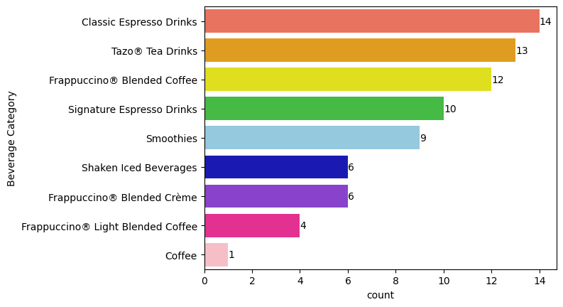

```python
# A simple bar chart to view counts of the drink options


	category_counts = sbux_grande['Beverage Category'].value_counts().index.tolist()

	ax = sns.countplot(y='Beverage Category', data=sbux_grande, order = category_counts, palette=bev_colors)
	ax.bar_label(ax.containers[0], fontsize=10)
	plt.show()
```

A horizontal bar chart, sorted based on the count of each beverage type, is easy to read by any stakeholder. We can easily see that the Classic Espresso Drinks category has the most distinct types at 14. The bottom of our list is the classic of all classics, the brewed Coffee. Why did we bother to sort out the drinks by size? If we were to rerun this example but with the full dataset we'd get a different view of this data.

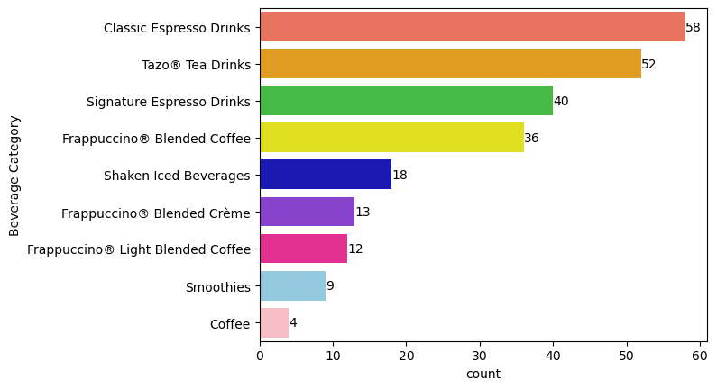

```python
# Another simple bar chart to view counts of the drink options, this time based on our original dataset


	category_counts = sbux_data['Beverage Category'].value_counts().index.tolist()

	ax = sns.countplot(y='Beverage Category', data=sbux_data, order = category_counts, palette=bev_colors)
	ax.bar_label(ax.containers[0], fontsize=10)
	plt.show()
```

Two things should be immediately noticable. One is that the total counts jumped up dramatically. This is because we are now including all size options for all drinks. The count of total items has increased because of the increased possible combinations. The other item that jumps out is that our rainbow is now out of sync. We intentionally kept the colors the same to visually identify changes. Adding in the additional size options bumped up the Signature Espresso Drinks and the Shaken Iced Beverages. Because the Smoothies only come in Grande they took a tumble. Is this visual incorrect compared to the first? That depends. If the analysis is on every permutation of the available drinks then this would get us closer to a correct count. Since we've already determined that there are gaps we elected not to pursue (beverages that could be either iced or hot, and the additional tea options with caffeine), we would be understating our counts. If the analysis is on base beverage types then it would be an overstatement of the menu. For a cleaner and more equitable understanding of nutitrional value by beverage type we'll continue to utilize the Grande only dataset.

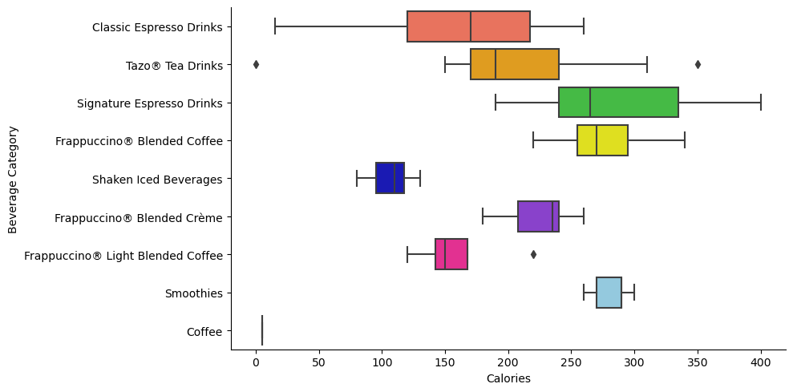

```python
# Now we know our counts by category, but where does that get us?
	# We can drill down into more specific nutirional information. Understanding the calorie content of drinks in each category
	# is a good place to start. It appears that drink categories with the most options also have the greatest variation in
	# calorie contents.

	sns.catplot(data=sbux_grande,
			   x="Calories",
			   y="Beverage Category",
			   kind = "box",
			   aspect = 2,
			   order = category_counts,
			   palette=bev_colors)
```

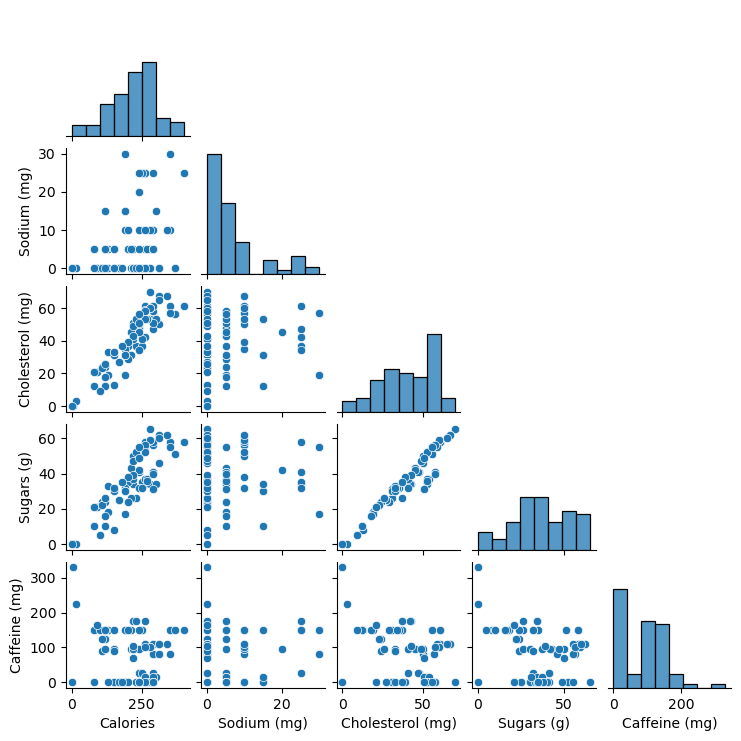

```python
# Let's reduce our dataset to a few of the nutritional facts that I'm most curious about.
	# Once those are skinnied down we'll create a pairplot to check for anything immediately interesting for further investigation.

	sbux_nutr = sbux_grande[['Calories','Total Fat (g)','Sodium (mg)','Cholesterol (mg)','Sugars (g)','Caffeine (mg)']]


	sns.pairplot(sbux_nutr, height = 1.5, corner = True)
```

There are some significant trends. We'll run through a few visualizations and see what else pops out to us

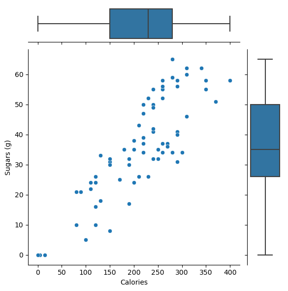

```python
# Sugar and Calories are an obvious place to start. Using a scatter plot paired with box and whiskers we can see
	# where these drinks tend to land in relation to each other.


	ax = sns.JointGrid(data=sbux_grande, x="Calories", y="Sugars (g)")
	ax.plot(sns.scatterplot, sns.boxplot)
```

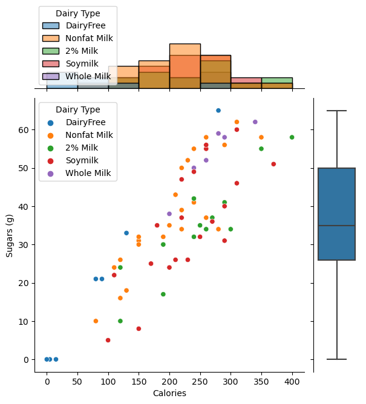

```python
# Let's try a couple variations on this theme, and drill down into further attributes. Dairy and non-dairy milks contain
	# added sugars, we'll add a color dimension based on Dairy_Type to check for trends.

	g = sns.JointGrid()
	x, y = sbux_grande["Calories"], sbux_grande["Sugars (g)"]
	sns.scatterplot(x=x,y=y, hue=sbux_grande["Dairy Type"], ax=g.ax_joint)
	sns.histplot(x=x, hue=sbux_grande["Dairy Type"], ax=g.ax_marg_x)
	sns.boxplot(y=y, hue=sbux_grande["Dairy Type"], ax=g.ax_marg_y)
```

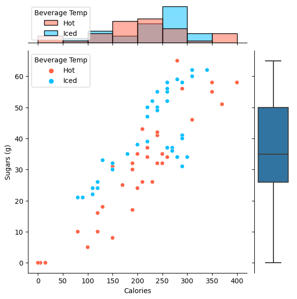

```python
# Dairy didn't indicate anything immediately obvious, other than the fact that ingredients
	# outside of milk and/or coffee must be contributing to the sugar content of these drinks.
	# Running this same exercise but with a split based on temperature indicates a stronger trend.

	# It would appear on first glance that the Iced Beverages tend to have higher Sugar content,
	# which would in turn push the Calorie count higher.


	g = sns.JointGrid()
	x, y = sbux_grande["Calories"], sbux_grande["Sugars (g)"]
	sns.scatterplot(x=x,y=y, hue=sbux_grande["Beverage Temp"], palette=temp_colors, ax=g.ax_joint)
	sns.histplot(x=x, hue=sbux_grande["Beverage Temp"], palette=temp_colors, ax=g.ax_marg_x)
	sns.boxplot(y=y, ax=g.ax_marg_y)
```

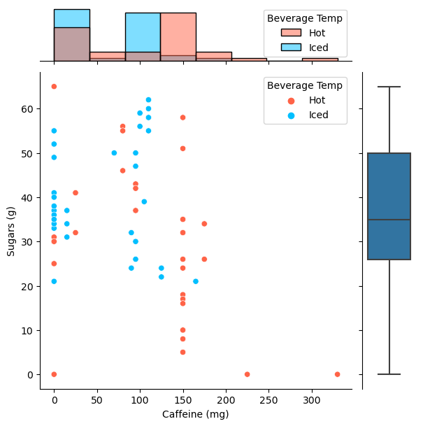

```python
# Caffeine content seems to have a strong banding by total, which would make sense knowing that a shot of espresso is a standard
	# size and is used in many drinks. There also seems to be a pattern to Hot vs. Iced drinks and caffeine content.

	g = sns.JointGrid()
	x, y = sbux_grande["Caffeine (mg)"], sbux_grande["Sugars (g)"]
	sns.scatterplot(x=x,y=y, hue=sbux_grande["Beverage Temp"], palette=temp_colors, ax=g.ax_joint)
	sns.histplot(x=x, hue=sbux_grande["Beverage Temp"], palette=temp_colors, ax=g.ax_marg_x)
	sns.boxplot(y=y, ax=g.ax_marg_y)
```

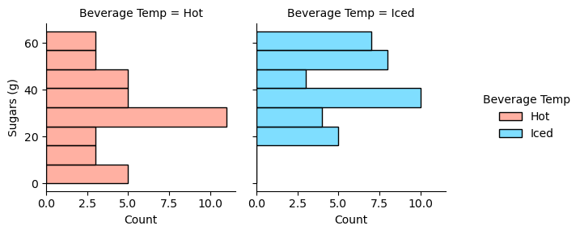

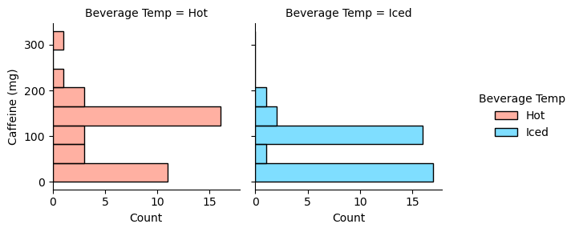

```python
# Each Hot and Iced drinks come in a variety of options by way of caffeination. What about the sugar content?
	# This appears to have a somewhat inverse relationship to caffeine, although there is significant overlap in hot drinks.
	# Iced drinks semm to be inherently sweetened. There are no iced drinks in our dataset that are free of sugar.

	sns.displot(sbux_grande,
				y="Sugars (g)",
				col="Beverage Temp",
				height=3,
				facet_kws=dict(margin_titles=True),
				hue="Beverage Temp",
				palette=temp_colors)
	sns.displot(sbux_grande,
				y="Caffeine (mg)",
				col="Beverage Temp",
				height=3,
				facet_kws=dict(margin_titles=True),
				hue="Beverage Temp",
				palette=temp_colors)
```

We've reviewed a few major cateries and begun to get a better feel for the data. At this point we'd start to game plan the next stages of an analysis. We've seen enough to have some good leads on future phases of the project. Decisions around who our audience is, what the purpose for the analysis is, and whether or not to look for additional data to incorporate and supplement this dataset will need to be made. We've identified a few gaps that could be filled already, but there are several opportunities to expand. Some easy examples of supplemental data could be: a more recent dataset with new drinks and the additional Trenta size to look at how the menu has evolved, sales data by beverage type and category to look for trends in product mix and time of year, or an expanded nutrition facts dataset with ingredients and stardard recipes.